# Idaho Department of Fish and Game

PopR Population Model Report

#### Model Definition

**Species:** *Mule Deer* **Unit:** *Boise River* **Years:** *1998*-*2015*

#### Future Harvest

**Males:** *1210* **Females:** *968*

#### Demographic Settings

**Adult Survival:** *Constant* **Juvenile Survival:** *Time Varying* **Recruitment:** *Time Varying*

#### Model Fitting

**MCMC Burnin:** *10000* **MCMC Reps:** *18000* **Thinning Rate:** *1*

#### Population Size

| Year | LowerCI | Total | UpperCI | LowerCI | Male | UpperCI | LowerCI | Female | UpperCI | LowerCI | Young | UpperCI |
| --- | --- | --- | --- | --- | --- | --- | --- | --- | --- | --- | --- | --- |
| 1998 | 20446 | 22572 | 25323 | 1566 | 1842 | 2195 | 11776 | 13194 | 15173 | 5889 | 7451 | 9746 |
| 1999 | 22162 | 24110 | 26757 | 1382 | 1604 | 1849 | 12579 | 13739 | 15311 | 7944 | 8762 | 9827 |
| 2000 | 22860 | 24720 | 27137 | 1701 | 1941 | 2204 | 12972 | 13996 | 15315 | 7964 | 8801 | 9863 |
| 2001 | 24023 | 25565 | 27466 | 1522 | 1730 | 1959 | 13265 | 14084 | 15132 | 8993 | 9753 | 10605 |
| 2002 | 25510 | 26953 | 28760 | 1932 | 2147 | 2410 | 13948 | 14661 | 15562 | 9372 | 10155 | 10999 |
| 2003 | 25728 | 26759 | 27888 | 1639 | 1824 | 2021 | 13610 | 14175 | 14822 | 10146 | 10754 | 11377 |
| 2004 | 22965 | 24053 | 25236 | 1932 | 2147 | 2368 | 13779 | 14355 | 14974 | 6923 | 7555 | 8212 |
| 2005 | 22353 | 23301 | 24282 | 1295 | 1481 | 1671 | 13298 | 13812 | 14381 | 7441 | 8006 | 8554 |
| 2006 | 22270 | 23313 | 24444 | 1435 | 1622 | 1821 | 13308 | 13856 | 14440 | 7212 | 7829 | 8494 |
| 2007 | 21645 | 22572 | 23595 | 1149 | 1326 | 1505 | 12841 | 13379 | 13949 | 7340 | 7868 | 8451 |
| 2008 | 20640 | 21657 | 22707 | 1190 | 1370 | 1555 | 12767 | 13334 | 13922 | 6384 | 6957 | 7541 |
| 2009 | 20550 | 21525 | 22628 | 1800 | 2026 | 2262 | 12366 | 12949 | 13559 | 6073 | 6558 | 7080 |
| 2010 | 23451 | 24558 | 25672 | 1893 | 2126 | 2377 | 11889 | 12499 | 13103 | 9373 | 9928 | 10498 |
| 2011 | 22234 | 23745 | 25241 | 1984 | 2147 | 2318 | 11573 | 12312 | 13069 | 8610 | 9280 | 9942 |
| 2012 | 19695 | 21597 | 23686 | 1805 | 2153 | 2536 | 11130 | 12015 | 12979 | 6418 | 7437 | 8534 |
| 2013 | 18341 | 21568 | 25165 | 1444 | 2067 | 2746 | 10777 | 11935 | 13175 | 5205 | 7570 | 10119 |
| 2014 | 17935 | 22055 | 26808 | 1550 | 2607 | 3842 | 10317 | 11895 | 13639 | 5133 | 7558 | 10278 |
| 2015 | 17499 | 22356 | 28162 | 1666 | 2962 | 4532 | 9882 | 11842 | 14098 | 5026 | 7536 | 10493 |

#### Sex & Age Ratios

| Year | LowerCI | M:F Ratio | UpperCI | LowerCI | Y:F Ratio | UpperCI |
| --- | --- | --- | --- | --- | --- | --- |
| 1998 | 0.13 | 0.14 | 0.15 | 0.42 | 0.56 | 0.77 |
| 1999 | 0.10 | 0.12 | 0.13 | 0.59 | 0.64 | 0.68 |
| 2000 | 0.13 | 0.14 | 0.15 | 0.59 | 0.63 | 0.68 |
| 2001 | 0.11 | 0.12 | 0.13 | 0.65 | 0.69 | 0.74 |
| 2002 | 0.13 | 0.15 | 0.16 | 0.65 | 0.69 | 0.74 |
| 2003 | 0.12 | 0.13 | 0.14 | 0.71 | 0.76 | 0.80 |
| 2004 | 0.14 | 0.15 | 0.16 | 0.48 | 0.53 | 0.57 |
| 2005 | 0.09 | 0.11 | 0.12 | 0.54 | 0.58 | 0.62 |
| 2006 | 0.11 | 0.12 | 0.13 | 0.52 | 0.57 | 0.61 |
| 2007 | 0.09 | 0.10 | 0.11 | 0.55 | 0.59 | 0.63 |
| 2008 | 0.09 | 0.10 | 0.11 | 0.48 | 0.52 | 0.56 |
| 2009 | 0.14 | 0.16 | 0.17 | 0.47 | 0.51 | 0.54 |
| 2010 | 0.15 | 0.17 | 0.19 | 0.75 | 0.80 | 0.84 |
| 2011 | 0.17 | 0.17 | 0.18 | 0.73 | 0.75 | 0.78 |
| 2012 | 0.16 | 0.18 | 0.20 | 0.55 | 0.62 | 0.69 |
| 2013 | 0.13 | 0.17 | 0.21 | 0.44 | 0.64 | 0.83 |
| 2014 | 0.15 | 0.22 | 0.29 | 0.44 | 0.64 | 0.83 |
| 2015 | 0.16 | 0.25 | 0.33 | 0.44 | 0.64 | 0.84 |

#### Survival

| Year | LowerCI | Juvenile Survival | UpperCI | LowerCI | Female Survival | UpperCI | LowerCI | Male Survival | UpperCI |
| --- | --- | --- | --- | --- | --- | --- | --- | --- | --- |
| 1998 | 0.48 | 0.62 | 0.76 | 0.86 | 0.87 | 0.88 | 0.61 | 0.65 | 0.69 |
| 1999 | 0.57 | 0.65 | 0.72 | 0.86 | 0.87 | 0.88 | 0.61 | 0.65 | 0.69 |
| 2000 | 0.49 | 0.58 | 0.66 | 0.86 | 0.87 | 0.88 | 0.61 | 0.65 | 0.69 |
| 2001 | 0.59 | 0.65 | 0.72 | 0.86 | 0.87 | 0.88 | 0.61 | 0.65 | 0.69 |
| 2002 | 0.37 | 0.44 | 0.50 | 0.86 | 0.87 | 0.88 | 0.61 | 0.65 | 0.69 |
| 2003 | 0.44 | 0.49 | 0.55 | 0.86 | 0.87 | 0.88 | 0.61 | 0.65 | 0.69 |
| 2004 | 0.54 | 0.61 | 0.69 | 0.86 | 0.87 | 0.88 | 0.61 | 0.65 | 0.69 |
| 2005 | 0.68 | 0.74 | 0.80 | 0.86 | 0.87 | 0.88 | 0.61 | 0.65 | 0.69 |
| 2006 | 0.55 | 0.62 | 0.69 | 0.86 | 0.87 | 0.88 | 0.61 | 0.65 | 0.69 |
| 2007 | 0.73 | 0.79 | 0.85 | 0.86 | 0.87 | 0.88 | 0.61 | 0.65 | 0.69 |
| 2008 | 0.59 | 0.67 | 0.75 | 0.86 | 0.87 | 0.88 | 0.61 | 0.65 | 0.69 |
| 2009 | 0.71 | 0.78 | 0.84 | 0.86 | 0.87 | 0.88 | 0.61 | 0.65 | 0.69 |
| 2010 | 0.42 | 0.47 | 0.52 | 0.86 | 0.87 | 0.88 | 0.61 | 0.65 | 0.69 |
| 2011 | 0.35 | 0.43 | 0.51 | 0.86 | 0.87 | 0.88 | 0.61 | 0.65 | 0.69 |
| 2012 | 0.54 | 0.66 | 0.77 | 0.86 | 0.87 | 0.88 | 0.61 | 0.65 | 0.69 |
| 2013 | 0.51 | 0.66 | 0.78 | 0.86 | 0.87 | 0.88 | 0.61 | 0.65 | 0.69 |
| 2014 | 0.51 | 0.66 | 0.78 | 0.86 | 0.87 | 0.88 | 0.61 | 0.65 | 0.69 |
| 2015 | 0.51 | 0.66 | 0.78 | 0.86 | 0.87 | 0.88 | 0.61 | 0.65 | 0.69 |

#### Population Trajectory

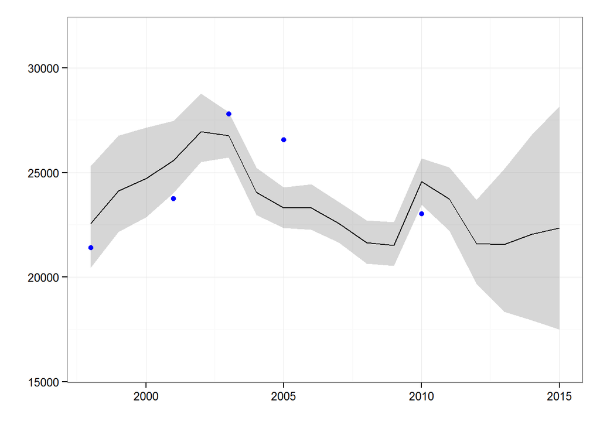

Figure 1. Model predicted population trajectory. Solid line represents the median estimate. The shaded area depcits the 95% prediction interval. Blue dots represent the mean of field base estimates.

#### Population Growth Rate

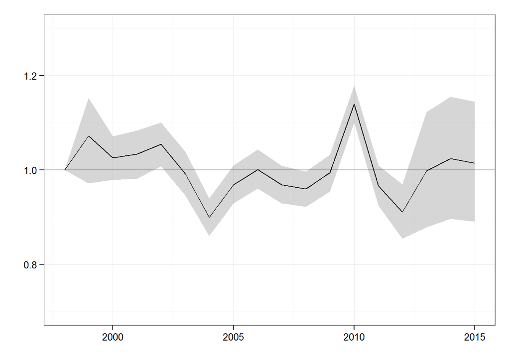

Figure 2. Model predicted population growth rate. The solid line represents the median estimate. The shaded area depcits the 95% prediction interval.

#### Survival

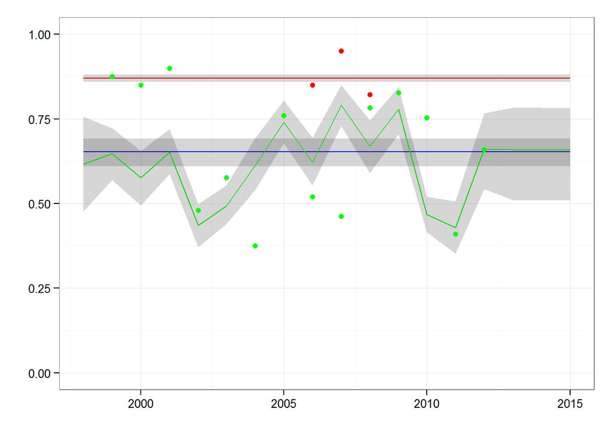

Figure 3. Model predicted survival of adult females (red), adult males (blue) and juveniles (green). Solid linesrepresents the median estimate. The shaded area depcits the 95% prediction interval for each series. Dots represent the mean of field base estimates.

#### Sex & Age Ratios

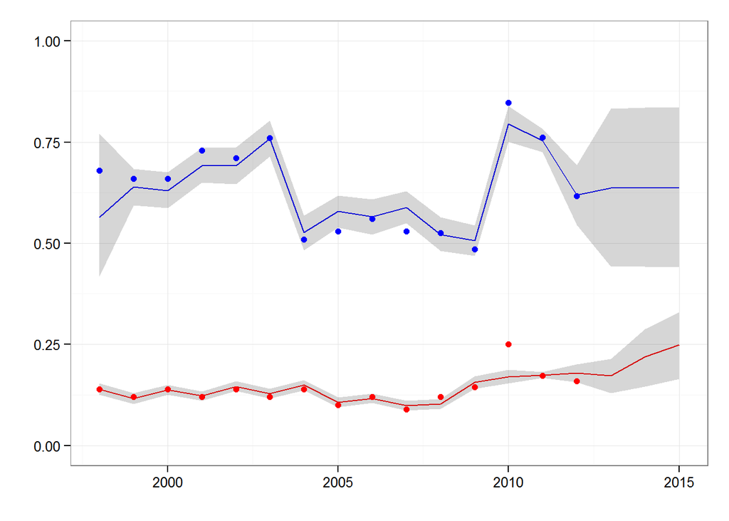

Figure 4. Model predicted ratios of young to adult females (blue) and adult males to adult females(red). Solid linesrepresents the median estimate while shaded area depcit 95% prediction intervals for each series. Dots represent the mean of field base estimates.